# HomeworkF_luel8892

```python
import numpy as np
import matplotlib.pyplot as plt
# importing the usual libraries and modules
```

## 1 Physics Background: The Spectrum of the Sun

#### The Planck Function

from homework B

y is what I will be using to represent lambda

$$ B(y,t) = \frac{2hc^2}{y^5(e^{hc/(ykT)}-1} $$

y - wavelength of light in meters

T = surface temperature of blackbody in Kelvin

h = 6.626*10^-34 J*s Planck's constant

c = 2.998*10^8 m/s speed of light

k = 1.381 * 10^-23 J/K Boltzmann's constant

B(y,t) gives the intensity of light

## 2 Coding Assignment: Finding local maxima

##### My Planck function from homework B

```python
#defining variables I will use

y= 7e-7 #wavelength of light in meters
#t= 6e3 #surface temperature of blackbody in Kelvin
t = 5800 #(kelvin) the tempureture given in homework F
h = 6.626e-34 #J*s Planck's constant
c = 2.998e8 #m/s speed of light
k = 1.381e-23 #J/K Boltzmann's constant




#B(y,t) gives the intensity of light\

# Creating the code for Planck function
def planck(y,t):
    '''
    ------input-----

    planck function takes two inputs(y,t)
    y is the wavelength in meters and can be either a float or an integer
    t is the surface temperature in Kelvin and can be either a float or an integer

    -----output------

    the planck functio returns a float value of B(y,t) which is the intensity and has units of
    Joules/ second / steradian / (meter^3)

    '''
    from math import e #importing the number e from the math module
    e = e


    B = (2*h*c**2)/((y**5)*(e**((h*c)/(y*k*t))-1)) #the planck function for intensity

    B_sci_notation = f"{B:.2e}"
    #return(B_sci_notation)
    #I will be using B for plotting in homework F
    return(B)
    '''
    '''



planck(1,1)
```

```
8.221064260217563e-15
```

#### 2.1 Plotting the Planck function for a temperature of 𝑇 = 5800 K

```python
x = np.linspace( 0, 100, 10) # creating a numpy array for x
print(x) # putting the numpy array for x into the Planck function
```

```
[  0.          11.11111111  22.22222222  33.33333333  44.44444444
  55.55555556  66.66666667  77.77777778  88.88888889 100.        ]
```

I will be using Wein's displacement law to calculate the peak wavelength for a temperature in Kelvin

Wein's displacement law:

$\lambda$<sub>peak</sub> = $$\frac{B}{T}$$

Wein's constant (B): B = 2.898 × 10⁻³ m⋅K

```python
def Wein_law(T): # the homework doesn;t say I can't use Wein's Law
    '''

    -----input------

    T = int or float
    The temperature of the blackbody in Kelvin

    ----function-------

    the function calculates the peak wavelength using weins displacement law

    ----return------

    the function returns the peak wavelength in meters

    '''

    B = 2.898*10**(-3) #m*K
    peak = B/T
    return(peak)
```

```python
print(Wein_law(1000)) #this should return 2.898 * 10^-6 meters
```

```
2.8980000000000005e-06
```

So my Wein's Law function for calculating the peak wavelength seems to be working! Now I will use it to calculate the peak wavelength of the temperature of 5800 kelvin. I will do this by creating an umpy array around 5800 kelvin and then inserting that into my Planck function

```python
# calculating the peak wavelength for a blackbody at 5800 kelvin
middle = Wein_law(5800)
print(middle)
```

```
4.996551724137931e-07
```

```python
xaxis1 = np.linspace(0.0000001, middle, 50) # making sure wavelength cannot be zero
two_middle = 2*middle
xaxis2 = np.linspace(middle, two_middle, 50)

xaxis = np.hstack((xaxis1, xaxis2)) #combining both halves of the x_axis to create the full x-axis

yaxis = []
for i in range(len(xaxis)):
    x = float(xaxis[i])
    if x != 0: #just double checking that x does not equal zero because if x == 0 then there will be a dividing be zero problem in the Planck function
        yaxis.append(planck(x,5800)) # adding the intensity of a wavelength a 5800 to the y axis list

print(len(yaxis) == len(xaxis)) #checking to make sue my two list are the same length
print(f"{max(yaxis):e}")

middle = middle *1e+6 # converting the middle alue to nanometers
xaxis = xaxis * 1e+6 # converting the x axis from meters to nanometers
```

```
True
2.691553e+13
```

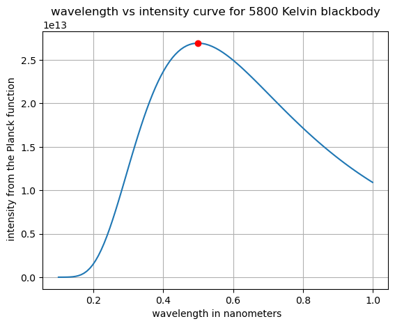

```python
#plotting the wavelength vs intensity curve for 5800 Kelvin blackbody
plt.plot(xaxis,yaxis)
plt.xlabel(" wavelength in nanometers")
plt.ylabel(" intensity from the Planck function")
plt.title("wavelength vs intensity curve for 5800 Kelvin blackbody")
plt.grid()


# I googled, "how to plot a point on a pyplot.plt in python" and this is roughly what I found
# plotting the max to make sure it lines u[ with my graph
x_coordinate = middle #the x coordina #getting the y value of the maxte of the max should be at 5800 which is the middle
y_coordinate = max(yaxis)
plt.plot(x_coordinate, y_coordinate, 'ro') # ploting the max
```

#### 2.2 Computing the derivative of the Planck function 𝑑𝐵/𝑑𝜆 over the range of wavelengths from 2.1

for calculating the derivative of the Planck function, I will use numpy.diff function. I will then plot two separate plots. First, I will plot the derivative on the plot of the function with arrows using quiver to make sure my derivatives are correct. Then I will create a separate plot of the drivtive as a function of wavelength.

```python
# Calculating the derivative

dB =[]
dx = []
print(len(dB))
print(len(dx))
x_pos = []
y_pos = []




for i in range(len(xaxis)):
    if i % 9 == 0 and i != 99: #this will create 11 value pf where my function will calculate the drivative and between 0.0 and 1.0 therre are 11 steps of 0.1

        B = np.diff(yaxis) #dBdx is the difference of values on the y axis, aka the derivative
        x = np.diff(xaxis)
        dB.append(B[i]) # making sure both derivatives have the same size as the xaxis array
        dx.append(x[i])

        #getting the position of each derivative
        x_pos.append(xaxis[i])
        y_pos.append(yaxis[i])
    else:
        i += 1
print(len(xaxis))
print(dB)
```

```
0
0
100
[683555707.5184557, 238576288612.72485, 968850755162.8164, 1056915355817.6074, 601153106197.8711, 134870281935.30469, -200033063346.1836, -388076662971.5625, -412796860235.6094, -370995152619.13086, -310708949672.8672]
```

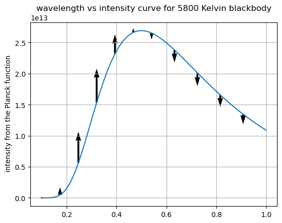

```python
#plotting the derivative with the actual planck function
x_direct = dx
y_direct = dB


plt.plot(xaxis,yaxis)
plt.quiver(x_pos, y_pos, x_direct, y_direct)
plt.title('derivative of the Placnk function dB/dlambda ')
plt.ylabel(" intensity from the Planck function")
plt.title("wavelength vs intensity curve for 5800 Kelvin blackbody")
plt.grid()

# Show plot
plt.show()
```

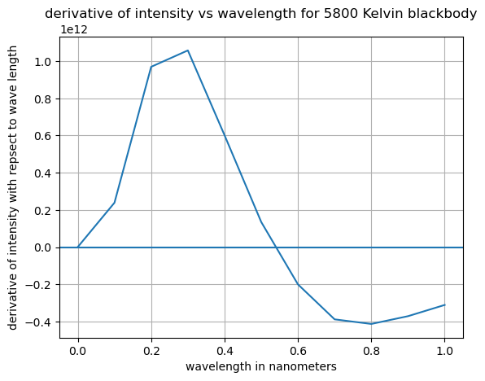

```python
x = np.linspace(0,1,11)
plt.plot(x, dB)
plt.ylabel("derivative of intensity with repsect to wave length")
plt.xlabel("wavelength in nanometers")
plt.title("derivative of intensity vs wavelength for 5800 Kelvin blackbody")
plt.axhline()
plt.grid()
```